# ΜΙΣΤΑ002: Mann-Whitney U test

## Mann-Whitney U test

The Mann-Whitney U test is used to compare two unrelated, or independent, samples and is often considered the nonparametric alternative to the two-sample t-test when there is violation of normality or for small sample sizes.

In this test the two samples are combined and rank ordered together. The strategy is to determine if the values from the two samples are randomly mixed in the rank ordering or if they are clustered at opposite ends when combined. A random rank order would mean that the two samples are not different, while a cluster of one sample's values would indicate a difference between them. In the following figure, two sample comparisons illustrate this concept.

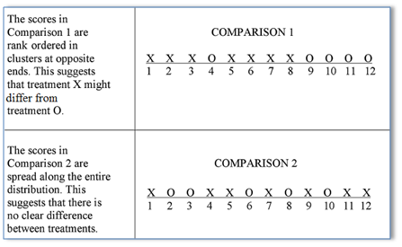

(modified from Corder GW, Foreman DI (2014). Nonparametric Statistics for Non-Statisticians: A Step-by-Step Approach (2nd Ed.), p.70)

**Assumptions**

- random samples have been drawn from the respective populations or the participants have been randomly assigned to two conditions
- each measurement or observation must correspond to a different participant. In statistical terms, there is independence within groups and mutual independence between groups
- there must be at least 4 observations in each group - otherwise the test cannot give a significant result irrespective of the difference between the two populations

**When the difference in the medians can be expressed in a null and alternative hypothesis****?**

If the distributions of the two groups have similar shapes (as in the below graph), the Mann-Whitney U test can be used to determine whether there are differences in the medians in the two groups.

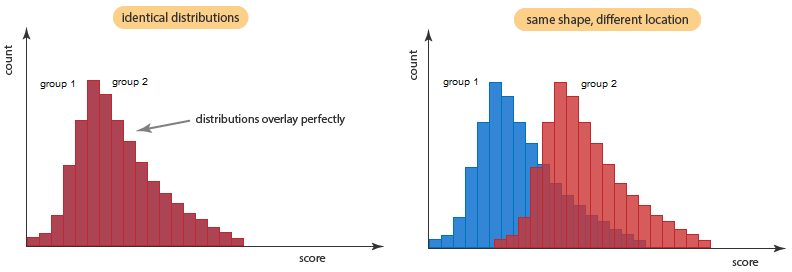

**Steps for conducting the test**

**Step 1. Define the null and alternative hypotheses under study**

**H<sub>0</sub>**: the two groups come from the same population (md<sub>1</sub>=md<sub>2</sub>).

**H<sub>1</sub>**: the two groups do not come from the same population (md<sub>1</sub>≠.md<sub>2</sub>)

**Step 2. Calculate the value of the test statistic specific to H<sub>0</sub>**

The Mann−Whitney U test statistic is the smaller of U<sub>1</sub> and U<sub>2</sub>.

Tied observations are assigned the mean of the ranks that would have received if they had not been tied.

**Step 3. Calculate the p value**

Again, an old fashioned way is to compare the U statistic (the smaller of U<sub>1</sub> and U<sub>2</sub>) with the critical values found at Mann-Whitney tables at the desirable level of significance (usually a=0.05), for a two-tailed test and for sample size of the two groups n<sub>1</sub> and n<sub>2</sub>. This method is rarely used anymore.

In practice we usually conduct the Mann-Whitney U test using statistical software (e.g. R, SPSS) that automatically provide the p-value.

**Step 4. Interpretation**

Interpretation of the results.

**Worked Example**

[figure not shown]

A new approach to prenatal care is proposed for pregnant women living in a rural community. The new program involves in-home visits during the course of pregnancy in addition to the usual or regularly scheduled visits. A pilot randomized trial with 15 pregnant women (small size) is designed to evaluate whether women who participate in the program deliver healthier babies than women receiving usual care. The outcome is the APGAR score measured 5 minutes after birth and the data for the two groups are shown below. Perform a two-tailed Mann-Whitney U test to answer the study question (a=0.05).

| **Usual care** | 8 | 7 | 6 | 2 | 5 | 8 | 7 | 3 |
| --- | --- | --- | --- | --- | --- | --- | --- | --- |
| **New program** | 9 | 8 | 7 | 8 | 10 | 9 | 6 |  |

APGAR scores range from 0 to 10 with scores of 7 or higher considered normal (healthy), 4-6 low and 0-3 critically low.

**Step 1. Define the null and alternative hypotheses under study**

**H<sub>0</sub>**: the two sample medians are the same (md<sub>1</sub>=md<sub>2</sub>)

**H<sub>1</sub>**: the two sample medians are not the same (md<sub>1</sub>≠md<sub>2</sub>)

**Step 2. Calculate the value of the test statistic specific to H<sub>0</sub>**

The first step is to rearrange the data from lowest to highest APGAR score while keeping track of group membership (first row in the table where usual care group is colored with yellow while new program with red). The next step is to assign a rank to each score from 1 to 15 (second row). Finally, reassign the ranks taking into account the tied observations and keeping track of group membership (yellow or red).

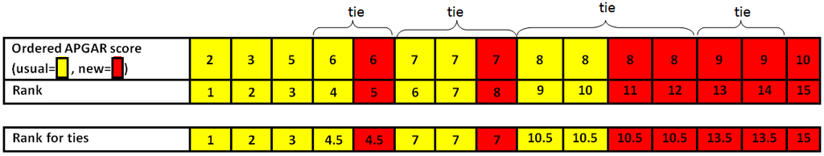

**Dealing with ties**

If there is a tie, all of the scores that tie receive the average rank of that set of scores (i.e. there is an observation with score 6 in each group. They each receive rank (4 + 5)/2 = 4.5).

Next, sum the ranks in each group. In the usual care group, the sum of the ranks (ranks in yellow) is ΣR<sub>1</sub>=1+2+3+4.5+7+7+10.5+10.5=45.5 (mean Rank=45.5/8=5.7) and in the new program group, the sum of the ranks (ranks in red) is ΣR<sub>2</sub>=4.5+7+10.5+10.5+13.5+13.5+15=74.5 (mean Rank=74.5/7=10.6).

For the two groups U<sub>1</sub> and U<sub>2</sub> are:

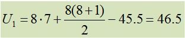

and

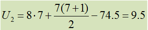

Thus, the test statistic is U=9.5.

If we run this test in R we will obtain the following:

[figure not shown]

**Step 3. Calculate the p value**

R gives a p value of 0.034 < 0.05.

**Step 4. Interpretation**  
There is significant evidence at α=0.05 that the APGAR scores are lower in women receiving usual prenatal care (median (IQR) = 6.5 (4.5, 7.25) ) as compared to the new program of prenatal care (median (IQR)= 8.0 (7.5, 9.0), (p=0.034).

Last modified: Thursday, 23 April 2020, 12:04 PM